# Discrete Probability Calculations

Yiwen Chen

9/25/2021

## Introduction

**How often does the better team win the World Series?**

The world series is a best-of-7 match-up between the champions of the American and National Leagues of Major League Baseball. I am going to explain probability calculations related to the world series, which may helps our general audience to figure out how often the better team win the World Series.

## Background

### Setup

To help our audience to figure out this topic easily:

**1.** I set up that **Braves** and **Yankees** are teams competing in the World Series.

**2.** I set up that in any given game, the probability that the Braves win is **P<sub>B</sub>** and the probability that the Yankees win is **P<sub>Y</sub>=1−P<sub>B</sub>**.

### Questions

I list 5 questions as follow to help you understand data science concept in this topic:

**1.** What is the probability that the Braves win the World Series given that P<sub>B</sub>=0.55?

**2.** What is the probability that the Braves win the World Series given that P<sub>B</sub>=x?

**3.** Suppose one could change the World Series to be best-of-9 or some other best-of-X series. What is the shortest series length so that P(Braves win World Series| P<sub>B</sub>=0.55)≥0.8?

**4.** What is the shortest series length so that P(Braves win World Series| P<sub>B</sub>=x) ≥ 0.8?

**5.** Calculate P(P<sub>B</sub>=0.55|Braves win World Series in 7 games) under the assumption that either P<sub>B</sub>=0.55 or P<sub>B</sub>=0.45.

### Stopping Rules

I will briefly explain the rules of winning the World Series:

To win the World Series, **Team** needs to win more than **half** of the **total** games. For example, if Braves win 4 games in the best-of-7 match-up, when the Braves get the 4th winning, the World Series would stop and the Braves win the championship. So, there is up to 7 games, and if one team get the 4th win, the world series would be end, and the team win the last game would be the winner.

PS:The results of every single game is independent.

## Methods

```r
library(ggplot2)
library(dplyr)
```

### 1.What is the probability that the Braves win the World Series given that P<sub>B</sub>=0.55?

In this question, if Braves win the World Series, they would win the last game, and have 3 wins in previous games, but have at most 3 loses in previous games. So the the probability that the Braves win the World Series is:

```r
pnbinom(3,4,0.55)
```

```
## [1] 0.6082878
```

The probability that the Braves win the World Series given that P<sub>B</sub>=0.55 is *0.6082878*. So, based on P<sub>B</sub>=0.55, the Braves are more likely to win the World Series.

### 2.What is the probability that the Braves win the World Series given that P<sub>B</sub>=x?

This will be a figure (see below) with P<sub>B</sub> on the x-axis and P(Braves win World Series) on the y-axis.

I varied the P<sub>B</sub> to x: `x = (0,1), by=0.0001`. And the result would in a plot shown below:

```r
x <- seq(0,1,by = 0.0001 )
y <- pnbinom(3,4,x)
```

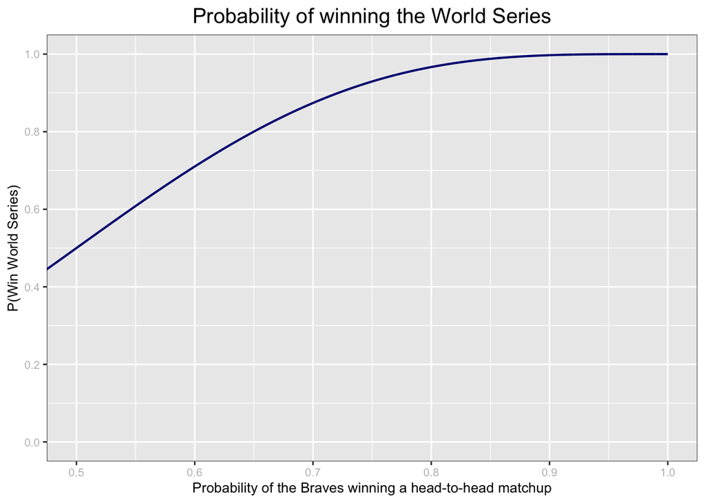

```r
df <- data.frame(x,y)

ggplot(
       df,
       aes(x, y)
       ) +
  geom_line(color = "navy",
            size = 0.75,
            alpha = 2) +
  scale_y_continuous(
                     breaks = seq(0, 1, 0.2),
                     ) +
  scale_x_continuous(
                     breaks = seq(0,1, 0.1),
                     ) +
  coord_cartesian(
                  xlim = c(0.5,1)
                  ) +
  labs(title = "Probability of winning the World Series",
       y = "P(Win World Series)",
       x = "Probability of the Braves winning a head-to-head matchup"
       ) +
  theme(axis.text = element_text(size = 8, color = "grey")
       ) +
  theme(
        axis.title = element_text(size = 10),
        plot.title = element_text(hjust = 0.5, size = 15)
       ) +
  theme(
        panel.border = element_rect(color = "black", size = 0.3, fill = NA)
       )
```

### 3.Suppose one could change the World Series to be best-of-9 or some other best-of-X series. What is the shortest series length so that P(Braves win World Series| P<sub>B</sub>=0.55)≥0.8?

For best-of-x series, if Braves win the World Series, they would win more than a half of `x` games, but lose at most `x/2 -1` games.(the `x` must be an odd number).

```r
matches_win = seq(4,1000, by = 1)
matches_loss = matches_win - 1
P_win_ws = pnbinom(matches_loss, matches_win, 0.55)
total_games = matches_win + matches_loss
total_games[which(P_win_ws >= 0.8)][1]
```

```
## [1] 71
```

Supposed that we could find a match the P(Braves win World Series| P<sub>B</sub>=0.55)≥0.8 in 1000 games of winning of Braves. The maximum number of its loss game is `matches_win - 1`. And then, it’s easy to calculate a `pnbinom(matches_loss, matches_win, 0.55)` and just choose the matches that could make `P_win_ws >= 0.8`. In conclusion, as the result, 71 is the shortest series length.

### 4.What is the shortest series length so that P(Braves win World Series| P<sub>B</sub>=x) ≥ 0.8?

This will be a figure (see below) with P<sub>B</sub> on the x-axis and series length is the y-axis.

I varied the P<sub>B</sub> to prob_win: `prob_win = (0.5,1), by=0.0001`. And then, I made a forloop to calculate the probabilities of Braves winning the World Series: `P_win_ws` by the different `prob_win`. And the result would in a plot shown below:

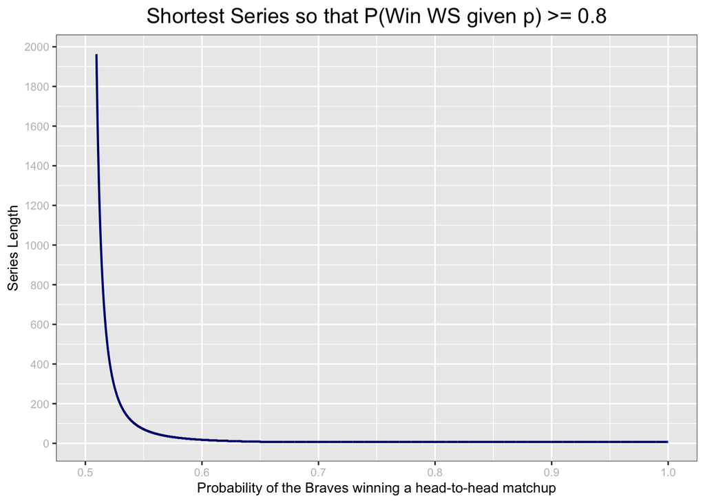

```r
prob_win = seq(0.5,1,by = 0.0001)
short_length = NA
for(i in 1:length(prob_win)){
  matches_win = seq(4,1000, by = 1)
  matches_loss = matches_win - 1
  P_win_ws = pnbinom(matches_loss, matches_win, prob_win[i])
  total_games = matches_win + matches_loss
  short_length[i] <- total_games[which(P_win_ws >= 0.8)[1]]
}
df <- data.frame(prob_win,short_length)
ggplot(
       df,
       aes(x = prob_win ,
           y = short_length)
       ) +
  geom_line(color = "navy",
            size = 0.75,
            alpha = 2) +
  scale_x_continuous(
                     breaks = seq(0.5,1, 0.1)
                     ) +
  scale_y_continuous(
                     breaks = seq(0,2000, 200)
                     ) +
  labs(title = "Shortest Series so that P(Win WS given p) >= 0.8",
       y = "Series Length",
       x = "Probability of the Braves winning a head-to-head matchup"
       ) +
  theme(axis.text = element_text(size = 8, color = "grey")
       ) +
  theme(
        axis.title = element_text(size = 10),
        plot.title = element_text(hjust = 0.5, size = 15)
       ) +
  theme(
        panel.border = element_rect(color = "black", size = 0.3, fill = NA)
       )
```

### 5.Calculate P(P<sub>B</sub>=0.55|Braves win World Series in 7 games) under the assumption that either P<sub>B</sub>=0.55 or P<sub>B</sub>=0.45.

Here is the `Bayes Rules` that I would use in the code chunks below:

$$P(A|B) = \frac{P(B|A)P(A)}{P(B)}$$
I use the parameters to match the `Bayes Rules`, P( A ) = P( P<sub>B</sub>=0.55 ), P( B ) = P( Braves win World Series in 7 games ).

P( P<sub>B</sub>=0.55 | Braves win World Series in 7 games ) = P( Braves win World Series in 7 games | P<sub>B</sub>=0.55 ) * P( P<sub>B</sub>=0.55 ) / P( Braves win World Series in 7 games )

So, if we are going to figure out the P( P<sub>B</sub>=0.55 | Braves win World Series in 7 games ), we have to get the result of P( Braves win World Series in 7 games | P<sub>B</sub>=0.55 ), P( P<sub>B</sub>=0.55 ), P( Braves win World Series in 7 games ).

Then, based on the assumption that either P<sub>B</sub>=0.55 or P<sub>B</sub>=0.45.

As a result, we could easily get P( P<sub>B</sub>=0.55 ) = 0.5;

Then use `dnbinom()` to calculate P( Braves win World Series in 7 games ) and P( Braves win World Series in 7 games | P<sub>B</sub>=0.55 ):

```r
#P(Braves win World Series in 7 games)
dnbinom(3,4,0.45)*0.5+dnbinom(3,4,0.55)*0.5
```

```
## [1] 0.1516092
```

```r
#P(Braves win World Series in 7 games|Pb=0.55)
dnbinom(3,4,0.55)
```

```
## [1] 0.1667701
```

P(Braves win World Series in 7 games) = 0.1516092, and P(Braves win World Series in 7 games | P<sub>B</sub>=0.55) = 0.1667701.

Finally, we can solve the problem using `Bayes Rules` and get the answer below:

```r
dnbinom(3,4,0.55)*0.5/(dnbinom(3,4,0.45)*0.5+dnbinom(3,4,0.55)*0.5)
```

```
## [1] 0.55
```

So, the P(P<sub>B</sub>=0.55|Braves win World Series in 7 games) under above assumptions is 0.55.